# GLMs and Quarter Review

Week 9

Published

March 6, 2025

# Before we start

[Download script](https://artur-baranov.github.io/nu-ps405-ds/scripts/ps405-d_9.qmd)

[Download data](https://artur-baranov.github.io/nu-ps405-ds/data/tjet.csv)

# Optional Review of the previous week

**Review**

Load `tidyverse` library

```r
library(tidyverse)
```

Load the European Social Value data (`ess.csv`).

Rename the variables:

- `pplfair` to `trust`
- `trstplt` to `trust_politicians`
- `rlgdgr` to `religion`

Run the following model. DV: `happy`, IVs: `trust`, `trust_politicians` and `religion`. Present the `summary()`.

Using `bptest()` from the `lmtest` library, test if the model is homoscedastic. Interpret the results of Breusch-Pagan test.

Draw residuals vs fitted plot. Does it match the BP test results? You can use `plot(..., which = 1)`.

Calculate the cutoff for the Cook’s distance using the formula: $\frac{4}{N-k-1}$. Plot the Cook’s distance using `plot()` and add a cutoff line using `abline()`. Are there any influential points?

Set up a model without influential points. How different the estimates are? Present a simple `modelsummary()` comparison.

```r
model_no = lm(happy ~ trust + trust_politicians + religion, ess[-c(...),])

library(...)
modelsummary(list(...),
             stars = T)
```

Draw a Q-Q plot using `plot(..., which = 2)` for the full model. Are the residuals distributed normally?

Using `shapiro.test()` test the normality of the `residuals` in the model. Interpret the results.

What else we have to check? How would you do that? No code needed but feel free to rely on the previous lab for this question.

# Agenda

- Recap of what we did
- And a short introduction to GLM alongside

# Recap

Today we are working with Transitional Justice Evaluation Tools dataset. You can explore their codebook [here](https://transitionaljusticedata.org/en/downloads.html). Let’s load the data.

```r
tjet = read.csv("data/tjet.csv")
```

Print out the first observations

```r
...(tjet)
```

We are going to use the following variables:

- `country` and `year`
- `dtr` democratic transition
- `tcs_operated` truth commission operated
- `trials_domestic` count of domestic trials per country and start year
- `region` United Nations region

Subset the above variables. You can do this with `select()`

```r
tjet_sub = ... %>%
  ...(country, year, dtr, tcs_operated, trials_domestic, region)
```

Leave more recent observations. Say, starting year 1975.

```r
tjet_sub = tjet_sub %>%
  ...(year >= 1975)
```

First, let’s explore the distribution of `trials_domestic` variable. Draw a histogram.

```r
...
```

Now, draw a boxplot of `trials_domestic` by `region`.

```r
ggplot(tjet_sub) +
  ...(aes(x = region, y = ...))
```

Now, present the descriptive statistics for the same variable (`trials_domestic`)

```r
...
```

Now, let’s do a slightly more detailed subgroup analysis. Calculate the average and median `trials_domestic` for all the regions. Save that to a new object. Why is the average so different from the median?

```r
trials_region = tjet_sub %>%
  ...(region) %>%
  ...(average_trials = ...(trials_domestic))

trials_region
```

Now, let’s the number of transitions (`dtr`). Why are there so many transitions?

```r
transitions_region = ...

transitions_region
```

Let’s visualize various statistics! Combine `trials_region` and `transitions_region` using `left_join()`. Draw a scatteplot. Let `transitions` be on the X axis, and `average_trials` on the Y axis. Add `geom_text()` with `label` argument set to `region`, use `vjust = 1.5`.

```r
trials_region %>%
  ...
  ggplot(...(x = ..., y = average_trials)) +
    geom_point(size = 4) +
    geom_text(aes(label = region), vjust = 1.5)
```

Using `ggpairs()` visualize the following columns: `"trials_domestic", "region", "tcs_operated", "dtr"`. What do you notice?

```r
library(...)
...
```

Set up a multiple linear regerssion. Predict democratic transition `dtr` by `trials_domestic` and `tcs_operated`. What type of model did we create based on the independent variables (IVs)? Present the results.

```r
model = ...
summary(model)
```

Load `ggeffects` library

```r
library(ggeffects)
```

Visualize the model with terms `trials_domestic` and `tcs_operated`.

```r
ggpredict(model, terms = c("trials_domestic", "tcs_operated")) %>%
  plot()
```

[output not shown]

Check the normality of residuals.

```r
...(model, which = 2)
```

Set the linear probability model, but include country and year fixed effects.

```r
model_lpm = lm(dtr ~ trials_domestic + tcs_operated + ..., tjet_sub)
```

Check the normality, again. Use Q-Q plot.

```r
plot(model_lpm, 2)
```

Now, let’s check if the residuals are homoscedastic. Use `which = 1` for `plot()`. What’s that? Can we fix that? Or even, should we?

```r
plot(model_lpm, 1)
```

# Logistic Regression

```r
model_glm = glm(dtr ~ trials_domestic + tcs_operated, tjet_sub, family = binomial(link = "logit"))
summary(model_glm)
```

[output not shown]

```r
ggpredict(model_glm, term = c("trials_domestic", "tcs_operated")) %>%
  plot(show_data = T)
```

[output not shown]

Compare to linear probability model **without** country and year fixed effects.

```r
ggpredict(model, term = c("trials_domestic", "tcs_operated")) %>%
  plot(show_data = T)
```

[output not shown]

Present both: linear probability model without fixed effects and logistic regression. The problem, though, that Logit is way harder to interpret! Stick to marginal effects, which we have covered in [lab 5](https://artur-baranov.github.io/nu-ps405-ds/ps405-d_5.html)!

```r
library(modelsummary)

modelsummary(list("LPM" = model,
                  "Logit" = model_glm),
             stars = T)
```

[output not shown]

A final note, in most cases you would expect to see logistic regression as something like

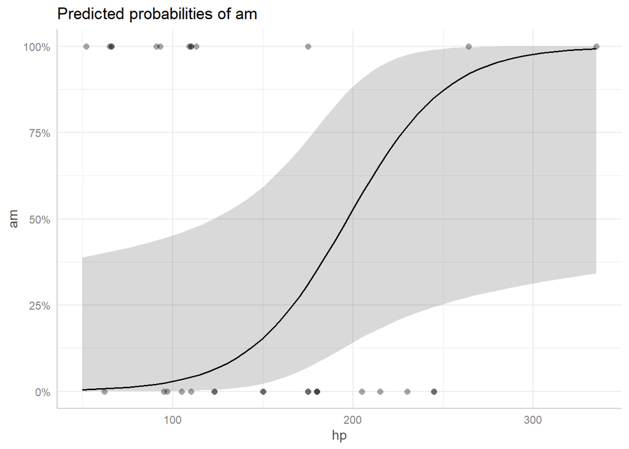

```r
glm(am ~ hp + wt, data = mtcars, family = binomial) %>%
  ggpredict(terms = c("hp")) %>%
  plot(show_data = T)
```

# What’s next?

Congrats with finalizing the class! No exercises this time.

- [Helpful resource for R](https://rstudio.github.io/cheatsheets/)
- Check the [main page](https://artur-baranov.github.io/nu-ps405-ds/) for additional resources
- Learning to code is like learning a new language: if you’re interested, keep practicing!
- I highly recommend taking POLI_SCI 406-0 Quantitative Causal Inference

# What we have covered in coding

| Library | Functions | Description |
| --- | --- | --- |
| tidyverse | `filter()`, `mutate()`, `ggplot()` | data wrangling and visualization |
| modelsummary | `modelsummary()` | present good looking tables |
| broom | `tidy()` | extract additional information from the models |
| ggeffects | `ggpredict()` | calculate and visualize marginal effects |
| GGally | `ggpairs()` | extension to ggplot |
| lmtest | `bptest()` | additional statistical tests for diagnostics |
| estimatr | `lm_robust()` | regression with robust and clustered standard errors |
| car | `vif()` | additional statistical tests for diagnostics |

# Datasets we have used

| Dataset | Description | Link |
| --- | --- | --- |
| **V-Dem** | Measures democracy worldwide | [V-Dem](https://www.v-dem.net/) |
| **World Happiness Report** | Annual happiness report | [World Happiness Report](https://worldhappiness.report/) |
| **Who Governs** | Dataset on political elites | [Who Governs](https://doi.org/10.1017/S0003055420000490) |
| **SIPRI** | Data on military operations | [SIPRI](https://www.sipri.org/databases) |
| **Comparative Political Data Set** | A dataset covering political institutions | [CPDS](https://www.cpds-data.org/) |
| **European Social Survey** | Survey measuring attitudes across Europe | [ESS](https://www.europeansocialsurvey.org/) |
| **Transitional Justice Evaluation Tools Dataset** | Dataset assessing transitional justice | [TJET Dataset](https://transitionaljusticedata.org) |

# Check list

I know that every lab has check list below! And I will use it to navigate what we have learned

I have developed the intuition behind application of quantitative methods